# CaseStudy1

```r
library(tidyverse)
#Reading the CSV file
df <- read.csv("E:/Assessment/loans_full_schema.csv")
view(df)
summary(df)
```

```
##   emp_title           emp_length       state           homeownership
##  Length:10000       Min.   : 0.00   Length:10000       Length:10000
##  Class :character   1st Qu.: 2.00   Class :character   Class :character
##  Mode  :character   Median : 6.00   Mode  :character   Mode  :character
##                     Mean   : 5.93
##                     3rd Qu.:10.00
##                     Max.   :10.00
##                     NA's   :817
##  annual_income     verified_income    debt_to_income   annual_income_joint
##  Min.   :      0   Length:10000       Min.   :  0.00   Min.   :  19200
##  1st Qu.:  45000   Class :character   1st Qu.: 11.06   1st Qu.:  86834
##  Median :  65000   Mode  :character   Median : 17.57   Median : 113000
##  Mean   :  79222                      Mean   : 19.31   Mean   : 127915
##  3rd Qu.:  95000                      3rd Qu.: 25.00   3rd Qu.: 151546
##  Max.   :2300000                      Max.   :469.09   Max.   :1100000
##                                       NA's   :24       NA's   :8505
##  verification_income_joint debt_to_income_joint   delinq_2y
##  Length:10000              Min.   : 0.32        Min.   : 0.000
##  Class :character          1st Qu.:14.16        1st Qu.: 0.000
##  Mode  :character          Median :19.72        Median : 0.000
##                            Mean   :19.98        Mean   : 0.216
##                            3rd Qu.:25.50        3rd Qu.: 0.000
##                            Max.   :39.98        Max.   :13.000
##                            NA's   :8505
##  months_since_last_delinq earliest_credit_line inquiries_last_12m
##  Min.   :  1.00           Min.   :1963         Min.   : 0.000
##  1st Qu.: 19.00           1st Qu.:1997         1st Qu.: 0.000
##  Median : 34.00           Median :2003         Median : 1.000
##  Mean   : 36.76           Mean   :2001         Mean   : 1.958
##  3rd Qu.: 53.00           3rd Qu.:2006         3rd Qu.: 3.000
##  Max.   :118.00           Max.   :2015         Max.   :29.000
##  NA's   :5658
##  total_credit_lines open_credit_lines total_credit_limit total_credit_utilized
##  Min.   : 2.00      Min.   : 0.0      Min.   :      0    Min.   :     0
##  1st Qu.:14.00      1st Qu.: 7.0      1st Qu.:  51594    1st Qu.: 19186
##  Median :21.00      Median :10.0      Median : 114667    Median : 36927
##  Mean   :22.68      Mean   :11.4      Mean   : 183606    Mean   : 51049
##  3rd Qu.:29.00      3rd Qu.:14.0      3rd Qu.: 267550    3rd Qu.: 65421
##  Max.   :87.00      Max.   :51.0      Max.   :3386034    Max.   :942456
##
```

[output cut: 81 more lines]

```
##  Length:10000           Length:10000        Min.   :    0   Min.   :    0.0
##  Class :character       Class :character    1st Qu.: 6679   1st Qu.:  928.7
##  Mode  :character       Mode  :character    Median :12380   Median : 1563.3
##                                             Mean   :14459   Mean   : 2494.2
##                                             3rd Qu.:20690   3rd Qu.: 2616.0
##                                             Max.   :40000   Max.   :41630.4
##
##  paid_principal    paid_interest    paid_late_fees
##  Min.   :    0.0   Min.   :   0.0   Min.   : 0.0000
##  1st Qu.:  587.1   1st Qu.: 221.8   1st Qu.: 0.0000
##  Median :  985.0   Median : 446.1   Median : 0.0000
##  Mean   : 1894.5   Mean   : 599.7   Mean   : 0.1195
##  3rd Qu.: 1694.6   3rd Qu.: 825.4   3rd Qu.: 0.0000
##  Max.   :40000.0   Max.   :4216.4   Max.   :52.9800
##
```

```r
sum(df$emp_title=="")    #833
```

```
## [1] 833
```

```r
#Creating a new data frame
df1 <- df[-which(df$emp_title==""),]
```

#Data Cleaning

Replacing NA values in annual income joint

Replacing NA values of months since last deliquency with 0 since their were no frauds in the line of credit.

Replacing NA values in month since 90 days late with 0 assuming that the applicants made payments on time.

Replacing NA values in months since last credit inquiry with 0

Replacing NA values in num accounts 120 days past due with 0 since the aggreagates of this column are zero.

```r
df1$annual_income_joint[is.na(df1$annual_income_joint)] <- mean(df$annual_income_joint,na.rm = TRUE)

df1$debt_to_income_joint[is.na(df1$debt_to_income_joint)] <- mean(df$debt_to_income_joint,na.rm = TRUE)

df1$months_since_last_delinq[is.na(df1$months_since_last_delinq)] <- 0

df1$months_since_90d_late[is.na(df1$months_since_90d_late)] <- 0

df1$months_since_last_credit_inquiry[is.na(df1$months_since_last_credit_inquiry)] <- 0

df1$num_accounts_120d_past_due[is.na(df1$num_accounts_120d_past_due)] <- 0

#Summary of data after cleaning it.
view(df1)
summary(df1)
```

```
##   emp_title           emp_length        state           homeownership
##  Length:9167        Min.   : 0.000   Length:9167        Length:9167
##  Class :character   1st Qu.: 2.000   Class :character   Class :character
##  Mode  :character   Median : 6.000   Mode  :character   Mode  :character
##                     Mean   : 5.929
##                     3rd Qu.:10.000
##                     Max.   :10.000
##
##  annual_income     verified_income    debt_to_income   annual_income_joint
##  Min.   :      0   Length:9167        Min.   :  0.00   Min.   :  26800
##  1st Qu.:  48500   Class :character   1st Qu.: 11.03   1st Qu.: 127915
##  Median :  68000   Mode  :character   Median : 17.43   Median : 127915
##  Mean   :  82184                      Mean   : 19.00   Mean   : 128532
##  3rd Qu.:  98714                      3rd Qu.: 24.76   3rd Qu.: 127915
##  Max.   :2300000                      Max.   :469.09   Max.   :1100000
##                                       NA's   :1
##  verification_income_joint debt_to_income_joint   delinq_2y
##  Length:9167               Min.   : 0.92        Min.   : 0.0000
##  Class :character          1st Qu.:19.98        1st Qu.: 0.0000
##  Mode  :character          Median :19.98        Median : 0.0000
##                            Mean   :19.96        Mean   : 0.2182
##                            3rd Qu.:19.98        3rd Qu.: 0.0000
##                            Max.   :39.98        Max.   :13.0000
##
##  months_since_last_delinq earliest_credit_line inquiries_last_12m
##  Min.   :  0.00           Min.   :1963         Min.   : 0.000
##  1st Qu.:  0.00           1st Qu.:1998         1st Qu.: 0.000
##  Median :  0.00           Median :2003         Median : 1.000
##  Mean   : 15.95           Mean   :2002         Mean   : 1.984
##  3rd Qu.: 29.00           3rd Qu.:2006         3rd Qu.: 3.000
##  Max.   :118.00           Max.   :2015         Max.   :26.000
##
##  total_credit_lines open_credit_lines total_credit_limit total_credit_utilized
##  Min.   : 2.00      Min.   : 0.00     Min.   :      0    Min.   :     0
##  1st Qu.:14.00      1st Qu.: 7.00     1st Qu.:  53658    1st Qu.: 20523
##  Median :21.00      Median :10.00     Median : 120282    Median : 38496
##  Mean   :22.85      Mean   :11.51     Mean   : 188803    Mean   : 53030
##  3rd Qu.:30.00      3rd Qu.:15.00     3rd Qu.: 273978    3rd Qu.: 67773
##  Max.   :87.00      Max.   :51.00     Max.   :3386034    Max.   :942456
##
```

[output cut: 81 more lines]

```
##  Length:9167        Length:9167            Length:9167         Min.   :    0
##  Class :character   Class :character       Class :character    1st Qu.: 6962
##  Mode  :character   Mode  :character       Mode  :character    Median :12938
##                                                                Mean   :14691
##                                                                3rd Qu.:21353
##                                                                Max.   :40000
##
##    paid_total      paid_principal    paid_interest    paid_late_fees
##  Min.   :    0.0   Min.   :    0.0   Min.   :   0.0   Min.   : 0.0000
##  1st Qu.:  954.1   1st Qu.:  601.6   1st Qu.: 226.2   1st Qu.: 0.0000
##  Median : 1607.6   Median : 1008.6   Median : 456.7   Median : 0.0000
##  Mean   : 2551.9   Mean   : 1940.9   Mean   : 611.0   Mean   : 0.1087
##  3rd Qu.: 2665.5   3rd Qu.: 1731.0   3rd Qu.: 843.6   3rd Qu.: 0.0000
##  Max.   :41630.4   Max.   :40000.0   Max.   :4216.4   Max.   :52.9800
##
```

#Visualizations

1. Plotting the house ownership status of the applicants who were granted loan where we can observe that people whose house are mortgage are the maximum applications who were given loans. People who had there own houses are the least applications for the loans.

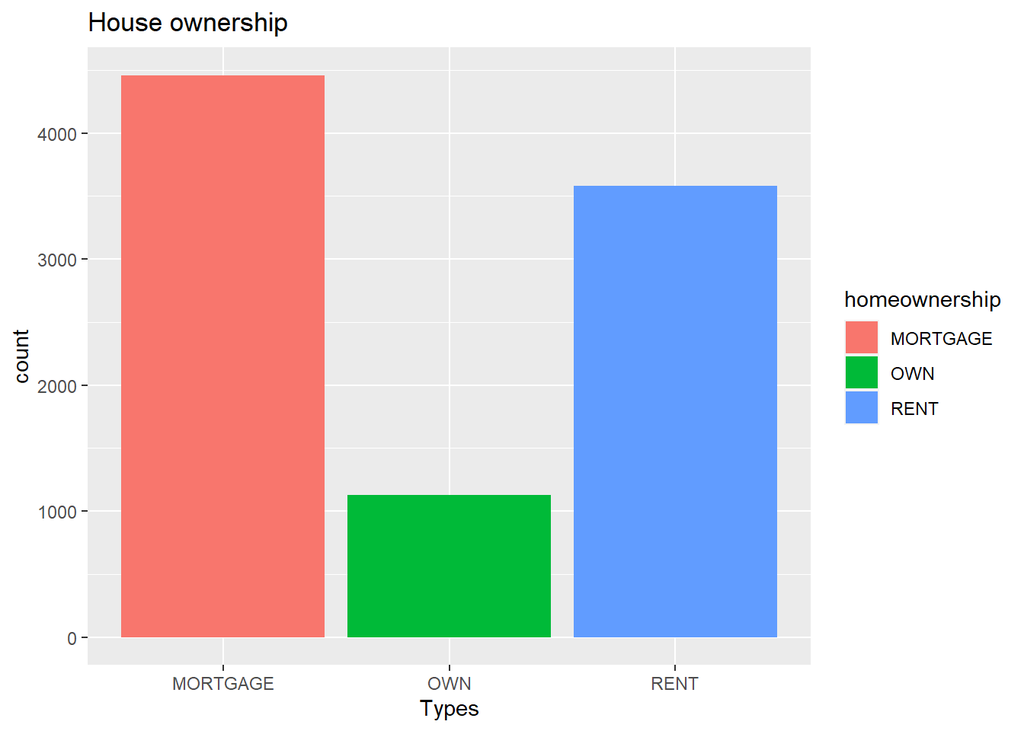

```r
df1%>% ggplot(aes(x=df1$homeownership,fill=homeownership)) +
              geom_bar()+
              labs(x="Types",title="House ownership")
```

2. Plotting boxplot

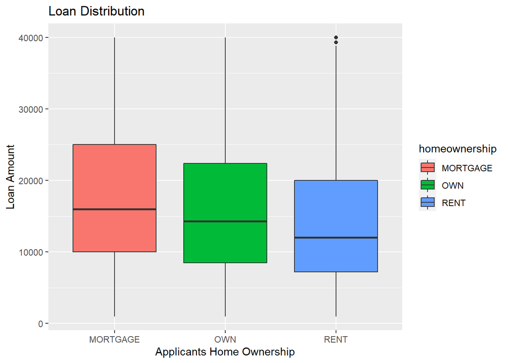

```r
df1_loan_amount <- df1%>% group_by(homeownership)

df1_loan_amount %>% ggplot(aes(x = homeownership, y = loan_amount, fill=homeownership)) +
                    geom_boxplot() +
                    labs(x="Applicants Home Ownership", y = "Loan Amount" , title = "Loan Distribution")
```

3. Plotting Grade vs interest rate to see the relationship between them. We can observe from the plot that as the grade increases the interest rate on the loan also goes on increasing.The application marked as A grade have the lowest interest rate and with applications G grade have the highest interest rate.

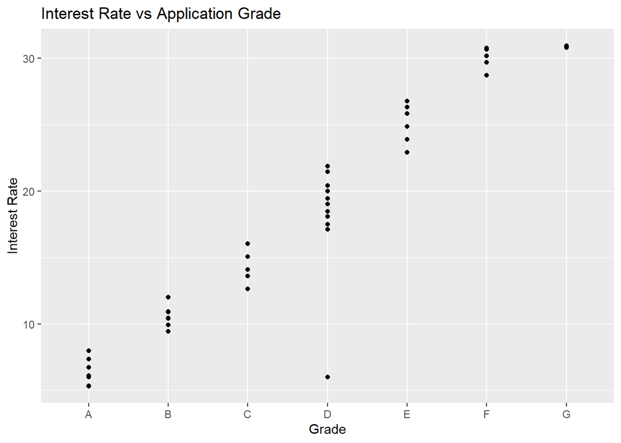

```r
df1 %>% ggplot(aes(x=grade ,y = interest_rate ,group = 1))+
  geom_point() +
  labs(x = "Grade",y = "Interest Rate" , title = "Interest Rate vs Application Grade")
```

4. Observing the distribution of Interest Rate. People are given more loans at interest rate of 10%. Higher the interest rate the applicants goes on decreasing.

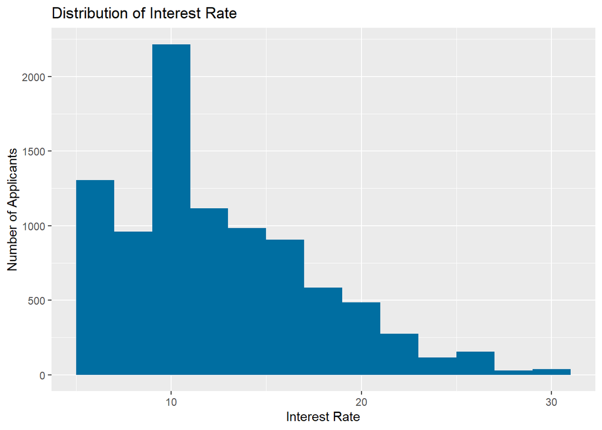

```r
df1 %>% ggplot(aes(x = interest_rate)) +
        geom_histogram(fill = "#006EA1",binwidth = 2)+
        labs(x = "Interest Rate", y = "Number of Applicants", title = "Distribution of Interest Rate")
```

5. Analysing the average loan amount and average interest rate given to the applicants based on the reason loans were taken for. Here we can observe that loans taken for vacation were given less loan amount with high average interest rate.

```r
df1_loan_purpose <- df1 %>% select(loan_purpose,loan_amount,interest_rate) %>%
                  group_by(loan_purpose) %>%
                  summarise(loan_amount = mean(loan_amount),
                            interest_rate = mean(interest_rate))

df1_loan_purpose
```

```
## # A tibble: 12 x 3
##    loan_purpose       loan_amount interest_rate
##    <chr>                    <dbl>         <dbl>
##  1 car                     10822.          12.0
##  2 credit_card             15723.          11.4
##  3 debt_consolidation      17941.          13.0
##  4 home_improvement        17496.          11.6
##  5 house                   17541.          11.6
##  6 major_purchase          15987.          11.9
##  7 medical                 11591.          12.2
##  8 moving                   9981.          13.0
##  9 other                   13268.          12.5
## 10 renewable_energy        14000           13.5
## 11 small_business          19937.          13.1
## 12 vacation                 7182.          13.3
```

#Machine Learning Models.